# R Notebook

**Brief Introduction**

*The nursing home data are provided by the Wisconsin Department of Health and Family Services (DHFS). The State of Wisconsin Medicaid program funds nursing home care for individuals qualifying on the basis of need and financial status. As part of the conditions for participation, Medicaid-certified nursing homes must file an annual cost report to DHFS, summarizing the volume and cost of care provided to all of its residents, Medicaid funded and otherwise. These cost reports are audited by DHFS staff and form the basis for facility-specific Medicaid daily payment rates for subsequent periods. Note: A nursing home is a facility for the residential care of elderly or disabled people.*

**Objective**

*The aim of this project is to develop a predictive model that provide reliable utilization forecast to update their Medicaid funding rate schedule of nursing facilities.*

**Data**

*The data here is in cost report years 2000 and 2001. There are 362 facilities in 2000 and 355 facilities in 2001. Typically, utilization of nursing home care is measured in patient days (“patient days” is the number of days each patient was in the facility, summed over all patients).*

#### **Exploratory Data Analysis**

**Information about the variables**

| File Name:WiscNursingHome | Number of obs: 717 | Number of variables: 12 |
| --- | --- | --- |
| **Variable (type of variable)** | **Number of Obs Missing** | **Description** |
| hospID (categorical) |  | Hospital identification number |
| CRYEAR (categorical binary) |  | Cost report year |
| TPY (quantitative continuous) |  | Total patient years |
| NUMBED (quantitative discrete) |  | Number of beds |
| SQRFOOT (quantitative continuous) | 10 | Square footage of the nursing home |
| MSA (categorical) |  | Metropol Statist Area code, 1-13, 0 for rural |
| URBAN (categorical Binary) |  | 1 if urban, 0 if rural |
| PRO (categorical Binary) |  | 1 if for profit, 0 for non-profit |
| TAXEXEMPT (categorical Binary) |  | 1 if tax-exempt |
| SELFFUNDINS (categorical Binary) |  | 1 if self-funded for insurance |
| MCERT (categorical Binary) |  | 1 if Medicare certified |
| ORGSTR (categorical) |  | 1 for profit, 2 for tax-exempt,3 for gov unit |

```r
datafile <- read.csv("WiscNursingHome.csv")
datafile
```

| hospID | CRYEAR | TPY | NUMBED | SQRFOOT | MSA | URBAN | PRO | TAXEXEMPT | SELFFUNDINS | MCERT | ORGSTR |
| --- | --- | --- | --- | --- | --- | --- | --- | --- | --- | --- | --- |
| 101 | 2000 | 16.48087 | 18.0 | 10.861 | 0 | 0 | 0 | 1 | 0 | 0 | 2 |
| 103 | 2000 | 59.24590 | 63.0 | 19.782 | 0 | 0 | 0 | 0 | 1 | 1 | 3 |
| 105 | 2000 | 49.63661 | 54.0 | 26.868 | 1 | 1 | 1 | 0 | 1 | 1 | 1 |
| 107 | 2000 | 51.87432 | 60.0 | 26.319 | 0 | 0 | 0 | 1 | 1 | 1 | 2 |
| 108 | 2000 | 94.56011 | 104.0 | 30.700 | 10 | 1 | 1 | 0 | 0 | 1 | 1 |
| 109 | 2000 | 69.70492 | 79.0 | 24.270 | 11 | 1 | 1 | 0 | 0 | 1 | 1 |
| 110 | 2000 | 95.56831 | 105.0 | 34.365 | 11 | 1 | 1 | 0 | 0 | 1 | 1 |
| 111 | 2000 | 95.15301 | 129.0 | 52.125 | 6 | 1 | 1 | 0 | 1 | 1 | 1 |
| 112 | 2000 | 193.16393 | 200.0 | 71.805 | 10 | 1 | 0 | 1 | 1 | 1 | 2 |
| 113 | 2000 | 156.36066 | 184.0 | 63.377 | 6 | 1 | 0 | 1 | 0 | 1 | 2 |

[output cut: 707 more lines]

**Analyzing variables distribution**

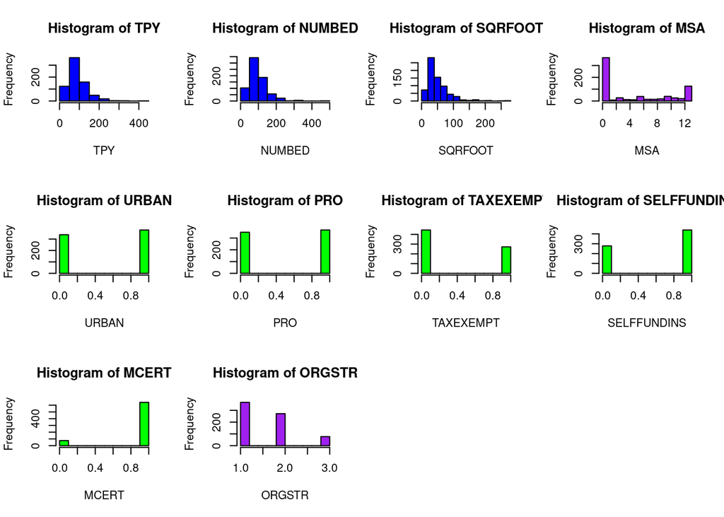

```r
# Set the layout of the graph
par(mfrow = c(3,4))

# Draw the first histogram
hist(datafile$TPY, main = "Histogram of TPY", xlab = "TPY", col = "blue")

# Draw the second histogram
hist(datafile$NUMBED, main = "Histogram of NUMBED", xlab = "NUMBED", col = "blue")

# Draw the third histogram
hist(datafile$SQRFOOT, main = "Histogram of SQRFOOT", xlab = "SQRFOOT", col = "blue")
hist(datafile$MSA, main = "Histogram of MSA", xlab = "MSA", col = "purple")
hist(datafile$URBAN, main = "Histogram of URBAN", xlab = "URBAN", col = "green")
hist(datafile$PRO, main = "Histogram of PRO", xlab = "PRO", col = "green")
hist(datafile$TAXEXEMPT, main = "Histogram of TAXEXEMPT", xlab = "TAXEXEMPT", col = "green")
hist(datafile$SELFFUNDINS, main = "Histogram of SELFFUNDINS", xlab = "SELFFUNDINS", col = "green")
hist(datafile$MCERT, main = "Histogram of MCERT", xlab = "MCERT", col = "green")
hist(datafile$ORGSTR, main = "Histogram of ORGSTR", xlab = "ORGSTR", col = "purple")
```

##### **Analysis of quantitative variables**

*Let’s see the summary statistics for the quantitative variables*

```r
summary(subset(datafile, select = c(TPY, SQRFOOT, NUMBED)))
```

```
##       TPY            SQRFOOT            NUMBED
##  Min.   : 11.57   Min.   :  5.644   Min.   : 18.0
##  1st Qu.: 56.71   1st Qu.: 28.638   1st Qu.: 60.0
##  Median : 80.93   Median : 39.883   Median : 90.0
##  Mean   : 89.25   Mean   : 50.257   Mean   : 97.2
##  3rd Qu.:109.12   3rd Qu.: 64.281   3rd Qu.:119.0
##  Max.   :440.67   Max.   :262.000   Max.   :457.0
##                   NA's   :10
```

*We can see the difference between the median and the mean which highlight right skewed distribution of the variables, let’s see this more clearly through a Box plot chart*

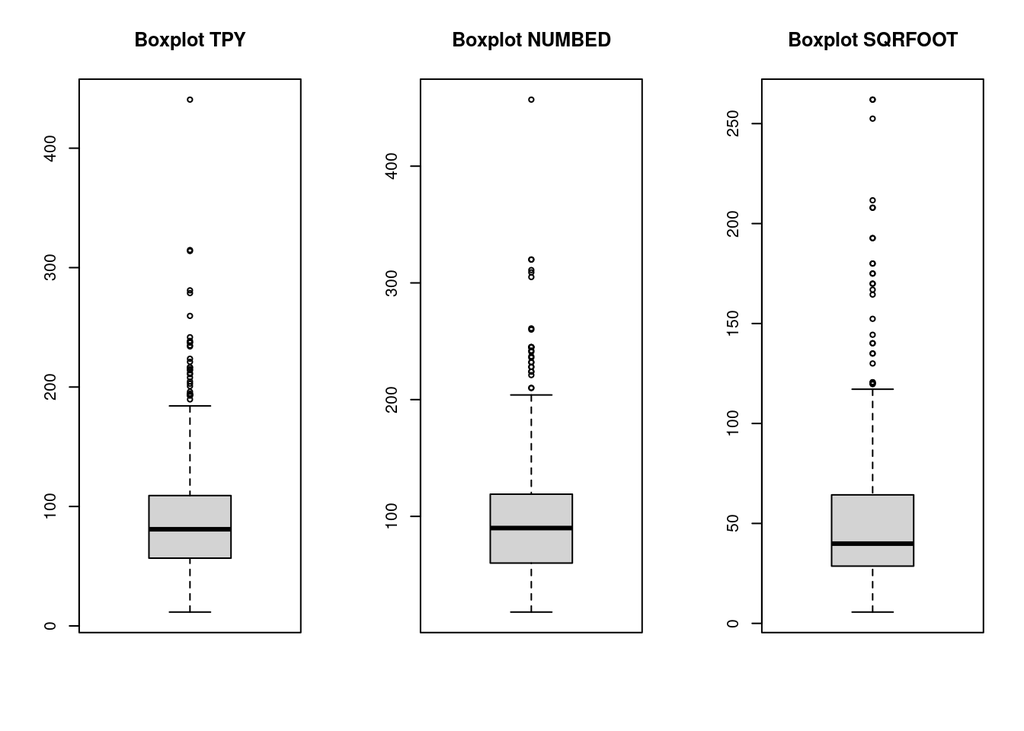

```r
par(mfrow = c(1, 3))

boxplot(datafile$TPY, main = "Boxplot TPY")

boxplot(datafile$NUMBED, main = "Boxplot NUMBED")

boxplot(datafile$SQRFOOT, main = "Boxplot SQRFOOT")
```

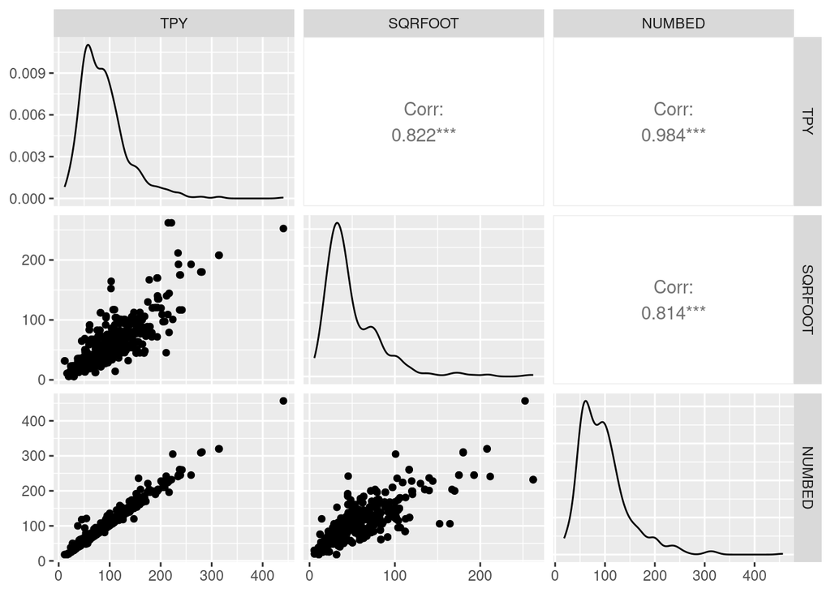

```r
library(ggplot2)
options(warn = - 1)
# install.packages("GGally")
library(GGally)
ggpairs(subset(datafile, select = c(TPY, SQRFOOT, NUMBED)))
```

*From the histograms and pair plots for the the non binary variables, we can see that the quantitative variables are skewed to the right. Then a log normal transformation of the variables should be useful for the statistical analysis*  
*The variable MSA have a bi modal distribution with modes in approximately 0 and 12.* *With respect to the correlation, the quantitative variables TRY and NUMBED are highly correlated (0,984). This high correlation means that both variables have the same information, which should be redundant to include in a single model. On the other hand, the correlation of SQRFOOT with TRY and NUMBED is around 0.818.*

```r
library("dplyr")
years_comparison <- datafile %>%
  group_by(hospID) %>%
  summarise(SQRFOOT_2000 =  SQRFOOT[CRYEAR == 2000], SQRFOOT_2001 =  SQRFOOT[CRYEAR == 2001],
            NUMBED_2000 = NUMBED[CRYEAR == 2000], NUMBED_2001 = NUMBED[CRYEAR == 2001],
            TPY_2000 =  TPY[CRYEAR == 2000], TPY_2001 =  TPY[CRYEAR == 2001],
            NUMBED_2000 = NUMBED[CRYEAR == 2000], NUMBED_2001 = NUMBED[CRYEAR == 2001],
            MSA_2000 =  MSA[CRYEAR == 2000], MSA_2001 =  MSA[CRYEAR == 2001],
            URBAN_2000 = URBAN[CRYEAR == 2000], URBAN_2001 = URBAN[CRYEAR == 2001],
            TAXEXEMPT_2000 =  TAXEXEMPT[CRYEAR == 2000], TAXEXEMPT_2001 =  TAXEXEMPT[CRYEAR == 2001],
            PRO_2000 = PRO[CRYEAR == 2000], PRO_2001 = PRO[CRYEAR == 2001],
            MCERT_2000 =  MCERT[CRYEAR == 2000], MCERT_2001 =  MCERT[CRYEAR == 2001],
            SELFFUNDINS_2000 = SELFFUNDINS[CRYEAR == 2000], SELFFUNDINS_2001 = SELFFUNDINS[CRYEAR == 2001],
            ORGSTR_2000 =  ORGSTR[CRYEAR == 2000], ORGSTR_2001 =  ORGSTR[CRYEAR == 2001])
years_comparison$NUMBED_diff <- years_comparison$NUMBED_2001-years_comparison$NUMBED_2000
years_comparison$SQRFOOT_diff <- years_comparison$SQRFOOT_2001-years_comparison$SQRFOOT_2000
```

```r
years_comparison
```

| hospID | SQRFOOT_2000 | SQRFOOT_2001 | NUMBED_2000 | NUMBED_2001 | TPY_2000 | TPY_2001 | MSA_2000 | MSA_2001 | URBAN_2000 | URBAN_2001 | TAXEXEMPT_2000 | TAXEXEMPT_2001 | PRO_2000 | PRO_2001 | MCERT_2000 | MCERT_2001 | SELFFUNDINS_2000 | SELFFUNDINS_2001 | ORGSTR_2000 | ORGSTR_2001 | NUMBED_diff | SQRFOOT_diff |
| --- | --- | --- | --- | --- | --- | --- | --- | --- | --- | --- | --- | --- | --- | --- | --- | --- | --- | --- | --- | --- | --- | --- |
| 101 | 10.861 | 10.861 | 18.0 | 18.0 | 16.48087 | 16.70411 | 0 | 0 | 0 | 0 | 1 | 1 | 0 | 0 | 0 | 0 | 0 | 1 | 2 | 2 | 0.0 | 0.000 |
| 103 | 19.782 | 19.782 | 63.0 | 50.0 | 59.24590 | 45.56986 | 0 | 0 | 0 | 0 | 0 | 0 | 0 | 0 | 1 | 1 | 1 | 1 | 3 | 3 | -13.0 | 0.000 |
| 105 | 26.868 | 26.868 | 54.0 | 54.0 | 49.63661 | 52.37808 | 1 | 1 | 1 | 1 | 0 | 0 | 1 | 1 | 1 | 1 | 1 | 1 | 1 | 1 | 0.0 | 0.000 |
| 107 | 26.319 | 26.319 | 60.0 | 60.0 | 51.87432 | 57.38356 | 0 | 0 | 0 | 0 | 1 | 1 | 0 | 0 | 1 | 1 | 1 | 1 | 2 | 2 | 0.0 | 0.000 |
| 108 | 30.700 | 30.700 | 104.0 | 104.0 | 94.56011 | 95.61096 | 10 | 10 | 1 | 1 | 0 | 0 | 1 | 1 | 1 | 1 | 0 | 1 | 1 | 1 | 0.0 | 0.000 |
| 109 | 24.270 | 24.270 | 79.0 | 79.0 | 69.70492 | 70.17260 | 11 | 11 | 1 | 1 | 0 | 0 | 1 | 1 | 1 | 1 | 0 | 1 | 1 | 1 | 0.0 | 0.000 |
| 110 | 34.365 | 34.365 | 105.0 | 105.0 | 95.56831 | 97.65479 | 11 | 11 | 1 | 1 | 0 | 0 | 1 | 1 | 1 | 1 | 0 | 1 | 1 | 1 | 0.0 | 0.000 |
| 111 | 52.125 | 46.030 | 129.0 | 108.0 | 95.15301 | 98.40000 | 6 | 6 | 1 | 1 | 0 | 0 | 1 | 1 | 1 | 1 | 1 | 1 | 1 | 1 | -21.0 | -6.095 |
| 112 | 71.805 | 71.785 | 200.0 | 200.0 | 193.16393 | 182.58904 | 10 | 10 | 1 | 1 | 1 | 1 | 0 | 0 | 1 | 1 | 1 | 1 | 2 | 2 | 0.0 | -0.020 |
| 113 | 63.377 | 63.377 | 184.0 | 184.0 | 156.36066 | 153.20000 | 6 | 6 | 1 | 1 | 1 | 1 | 0 | 0 | 1 | 1 | 0 | 0 | 2 | 2 | 0.0 | 0.000 |

[output cut: 341 more lines]

**Let’s transform the skewed quantitative variables with the log function**

```r
library(dplyr)
datafile_log <- datafile %>% mutate(TPY_log = log(TPY), NUMBED_log = log(NUMBED), SQRFOOT_log = log(SQRFOOT))
datafile_log
```

| hospID | CRYEAR | TPY | NUMBED | SQRFOOT | MSA | URBAN | PRO | TAXEXEMPT | SELFFUNDINS | MCERT | ORGSTR | TPY_log | NUMBED_log | SQRFOOT_log |
| --- | --- | --- | --- | --- | --- | --- | --- | --- | --- | --- | --- | --- | --- | --- |
| 101 | 2000 | 16.48087 | 18.0 | 10.861 | 0 | 0 | 0 | 1 | 0 | 0 | 2 | 2.802201 | 2.890372 | 2.385178 |
| 103 | 2000 | 59.24590 | 63.0 | 19.782 | 0 | 0 | 0 | 0 | 1 | 1 | 3 | 4.081697 | 4.143135 | 2.984772 |
| 105 | 2000 | 49.63661 | 54.0 | 26.868 | 1 | 1 | 1 | 0 | 1 | 1 | 1 | 3.904729 | 3.988984 | 3.290936 |
| 107 | 2000 | 51.87432 | 60.0 | 26.319 | 0 | 0 | 0 | 1 | 1 | 1 | 2 | 3.948824 | 4.094345 | 3.270291 |
| 108 | 2000 | 94.56011 | 104.0 | 30.700 | 10 | 1 | 1 | 0 | 0 | 1 | 1 | 4.549236 | 4.644391 | 3.424263 |
| 109 | 2000 | 69.70492 | 79.0 | 24.270 | 11 | 1 | 1 | 0 | 0 | 1 | 1 | 4.244271 | 4.369448 | 3.189241 |
| 110 | 2000 | 95.56831 | 105.0 | 34.365 | 11 | 1 | 1 | 0 | 0 | 1 | 1 | 4.559841 | 4.653960 | 3.537039 |
| 111 | 2000 | 95.15301 | 129.0 | 52.125 | 6 | 1 | 1 | 0 | 1 | 1 | 1 | 4.555486 | 4.859812 | 3.953645 |
| 112 | 2000 | 193.16393 | 200.0 | 71.805 | 10 | 1 | 0 | 1 | 1 | 1 | 2 | 5.263539 | 5.298317 | 4.273954 |
| 113 | 2000 | 156.36066 | 184.0 | 63.377 | 6 | 1 | 0 | 1 | 0 | 1 | 2 | 5.052165 | 5.214936 | 4.149101 |

[output cut: 707 more lines]

*Let’s see the summary statistics for the log transformed variables*

```r
summary(subset(datafile_log, select = c(TPY_log, NUMBED_log, SQRFOOT_log, TPY, SQRFOOT, NUMBED)))
```

```
##     TPY_log        NUMBED_log     SQRFOOT_log         TPY
##  Min.   :2.448   Min.   :2.890   Min.   :1.731   Min.   : 11.57
##  1st Qu.:4.038   1st Qu.:4.094   1st Qu.:3.355   1st Qu.: 56.71
##  Median :4.394   Median :4.500   Median :3.686   Median : 80.93
##  Mean   :4.364   Mean   :4.457   Mean   :3.727   Mean   : 89.25
##  3rd Qu.:4.692   3rd Qu.:4.779   3rd Qu.:4.163   3rd Qu.:109.12
##  Max.   :6.088   Max.   :6.125   Max.   :5.568   Max.   :440.67
##                                  NA's   :10
##     SQRFOOT            NUMBED
##  Min.   :  5.644   Min.   : 18.0
##  1st Qu.: 28.638   1st Qu.: 60.0
##  Median : 39.883   Median : 90.0
##  Mean   : 50.257   Mean   : 97.2
##  3rd Qu.: 64.281   3rd Qu.:119.0
##  Max.   :262.000   Max.   :457.0
##  NA's   :10
```

*It is clear that now the variables have a log normal distribution since the mean and the median are much closer as well as the first and fourth quantile, let’s see this graphically with histograms a box plots*

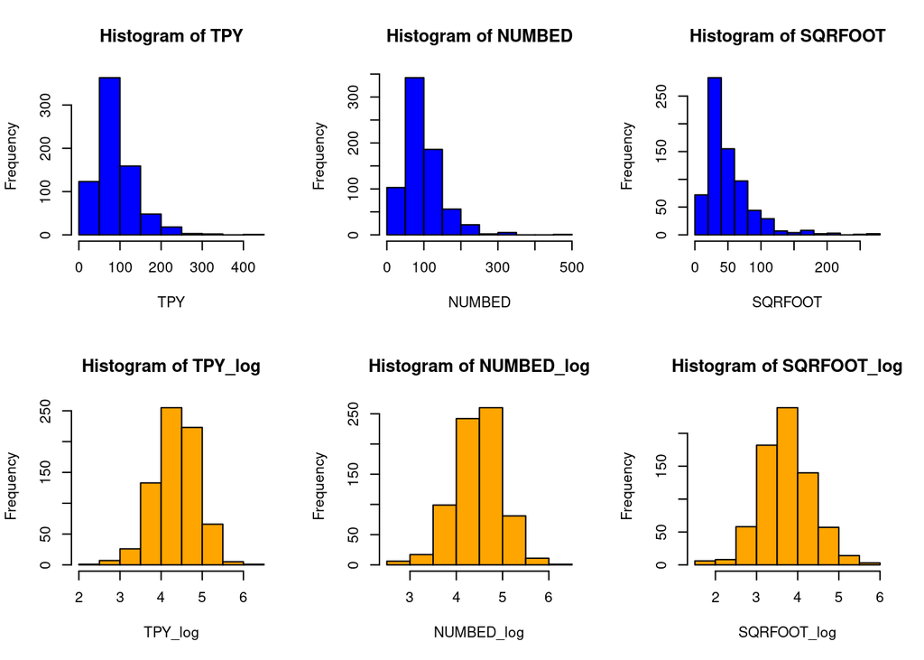

```r
# Set the layout of the graph
par(mfrow = c(2,3))

# Draw the first histogram
hist(datafile_log$TPY, main = "Histogram of TPY", xlab = "TPY", col = "blue")

# Draw the second histogram
hist(datafile_log$NUMBED, main = "Histogram of NUMBED", xlab = "NUMBED", col = "blue")

# Draw the third histogram
hist(datafile_log$SQRFOOT, main = "Histogram of SQRFOOT", xlab = "SQRFOOT", col = "blue")
hist(datafile_log$TPY_log, main = "Histogram of TPY_log", xlab = "TPY_log", col = "orange")
hist(datafile_log$NUMBED_log, main = "Histogram of NUMBED_log", xlab = "NUMBED_log", col = "orange")
hist(datafile_log$SQRFOOT_log, main = "Histogram of SQRFOOT_log", xlab = "SQRFOOT_log", col = "orange")
```

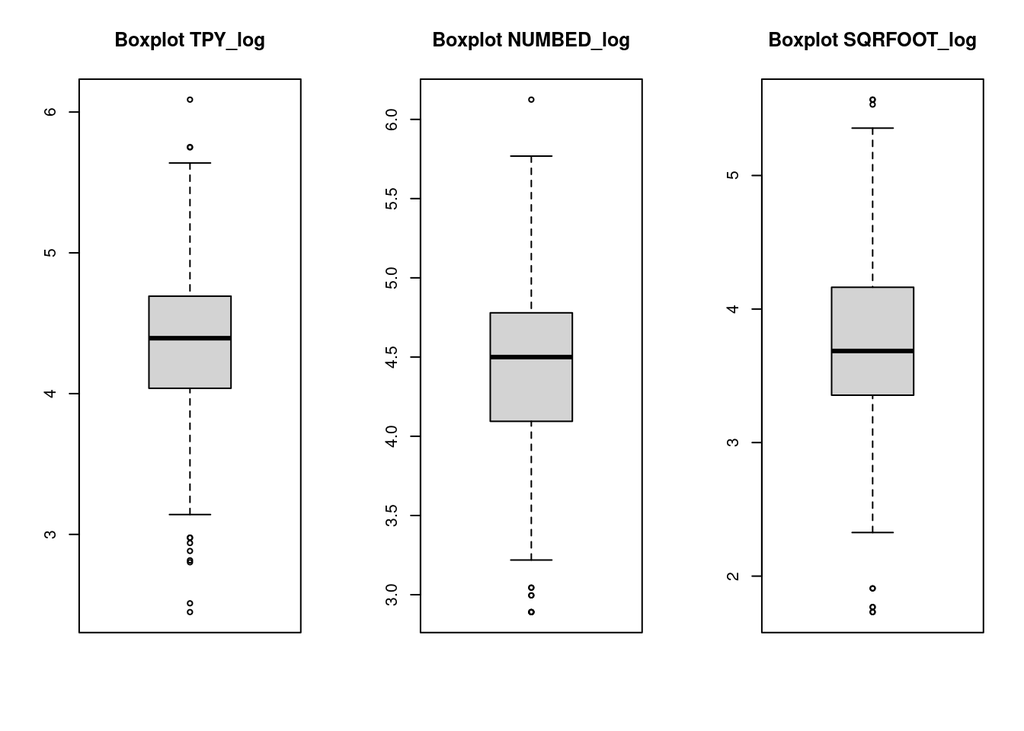

```r
par(mfrow = c(1, 3))

boxplot(datafile_log$TPY_log, main = "Boxplot TPY_log")

boxplot(datafile_log$NUMBED_log, main = "Boxplot NUMBED_log")

boxplot(datafile_log$SQRFOOT_log, main = "Boxplot SQRFOOT_log")
```

*After the log transformation of the variables, seems that many of the observations were considered outliers before, now they are included in the log-normal distribution. Besides, from the whiskers is easy to recognize that the distribution is approximately normal. Ending, in general, after the transformation, the mean of the three variables is closer. Let’s see what information we can extract from a pairplot of the transformed variables*

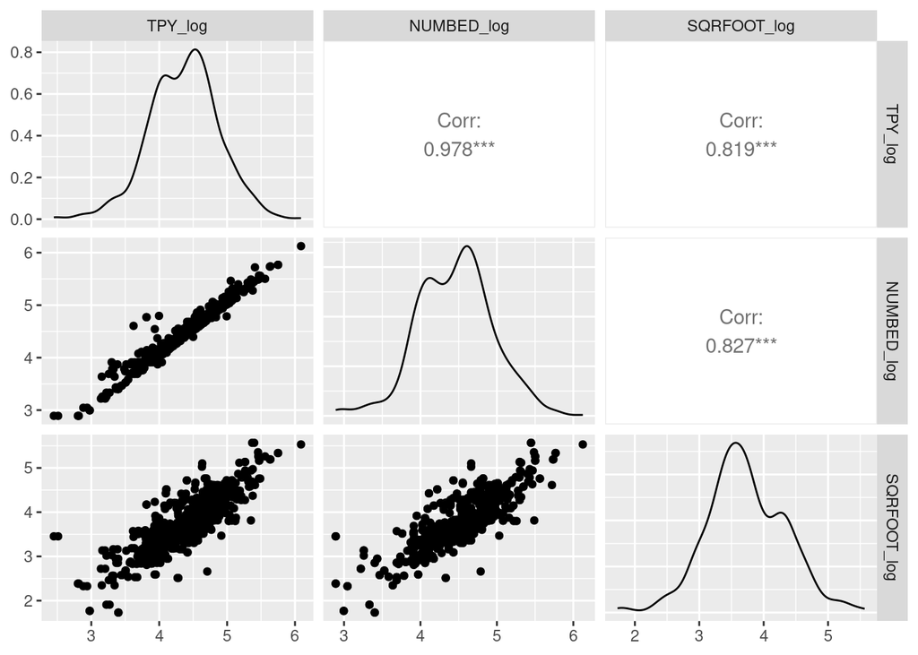

```r
options(warn = - 1)
library(ggplot2)
library(GGally)
ggpairs(subset(datafile_log, select = c(TPY_log, NUMBED_log, SQRFOOT_log)))
```

##### *Analysis of categorical variables*

Let’s analyse the relationship between explained variable TPY and categorical variables of the dataset.

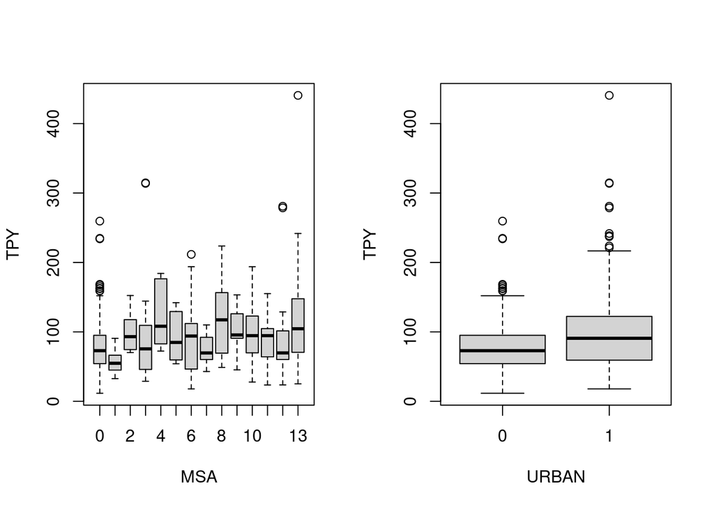

```r
par(mfrow=c(1,2))
boxplot(TPY ~ MSA, data = datafile, horizontal = FALSE,
        xlab = "MSA", ylab = "TPY")
boxplot(TPY ~ URBAN, data = datafile, horizontal = FALSE,
        xlab = "URBAN", ylab = "TPY")
```

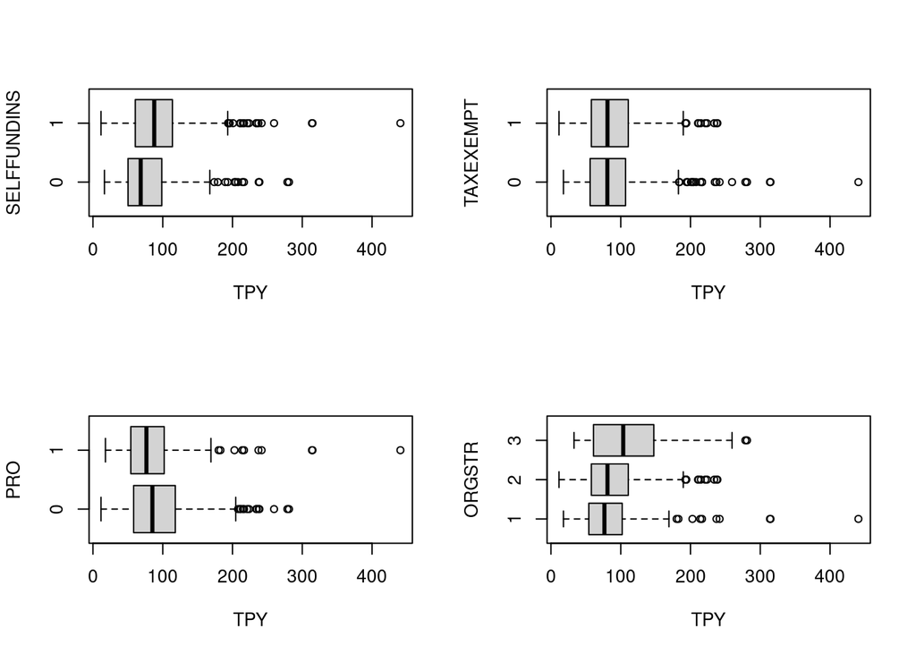

```r
par(mfrow=c(2,2))
boxplot(TPY ~ SELFFUNDINS, data = datafile, horizontal = TRUE,
        ylab = "SELFFUNDINS", xlab = "TPY")
boxplot(TPY ~ TAXEXEMPT, data = datafile, horizontal = TRUE,
        ylab = "TAXEXEMPT", xlab = "TPY")
boxplot(TPY ~ PRO, data = datafile, horizontal = TRUE,
        xlab = "TPY", ylab = "PRO")
boxplot(TPY ~ ORGSTR, data = datafile, horizontal = TRUE,
        xlab = "TPY", ylab = "ORGSTR")
```

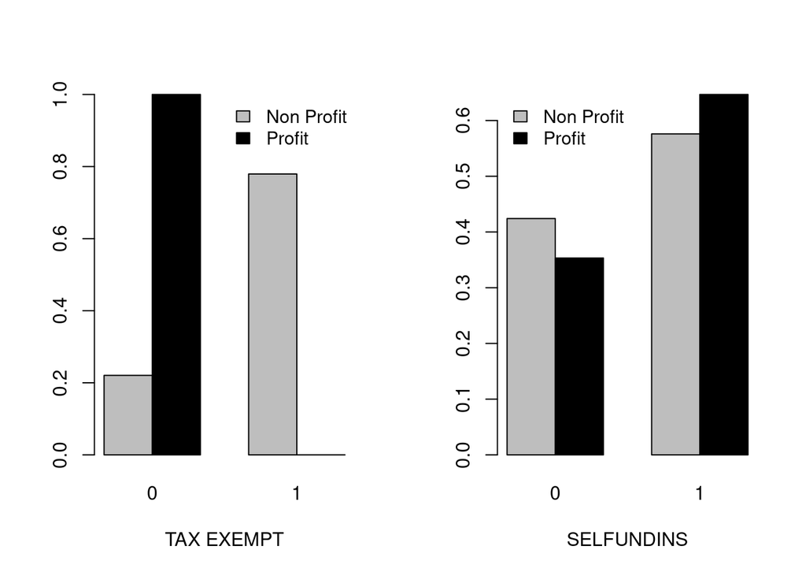

```r
par(mfrow = c(1, 2))
barplot(prop.table(table(datafile$PRO, datafile$TAXEXEMPT), margin = 1),
        beside=TRUE, xlab="TAX EXEMPT",col=c("gray","black"))
legend("topright", c("Non Profit", "Profit"), cex = 0.95, bty = "n",fill=c("gray","black"))


barplot(prop.table(table(datafile$PRO, datafile$SELFFUNDINS), margin = 1),
        beside=TRUE, xlab="SELFUNDINS",col=c("gray","black"))
legend("topleft", c("Non Profit", "Profit"), cex = 0.95, bty = "n",fill=c("gray","black"))
```

##### *Data pre-processing*

**Missing values processing**

```r
library(dplyr)
#DATA CLEANING
datafile <- na.omit(datafile) #drop NAs
```

```r
datafile$UTILIZATION_RATE <- datafile$TPY / datafile$NUMBED
```

**Transform into categorical variables**

```r
#Transform into categorical variables
datafile$ORGSTR <- as.factor(datafile$ORGSTR)
datafile$MSA <- as.factor(datafile$MSA)
```

**Selection, description, and possibly comparison of the most suitable statistical models**

```r
df_2000 <- datafile[datafile$CRYEAR == "2000", ]
df_2000
```

|  | hospID | CRYEAR | TPY | NUMBED | SQRFOOT | MSA | URBAN | PRO | TAXEXEMPT | SELFFUNDINS | MCERT | ORGSTR | UTILIZATION_RATE |
| --- | --- | --- | --- | --- | --- | --- | --- | --- | --- | --- | --- | --- | --- |
| 1 | 101 | 2000 | 16.48087 | 18.0 | 10.861 | 0 | 0 | 0 | 1 | 0 | 0 | 2 | 0.9156041 |
| 2 | 103 | 2000 | 59.24590 | 63.0 | 19.782 | 0 | 0 | 0 | 0 | 1 | 1 | 3 | 0.9404111 |
| 3 | 105 | 2000 | 49.63661 | 54.0 | 26.868 | 1 | 1 | 1 | 0 | 1 | 1 | 1 | 0.9191965 |
| 4 | 107 | 2000 | 51.87432 | 60.0 | 26.319 | 0 | 0 | 0 | 1 | 1 | 1 | 2 | 0.8645719 |
| 5 | 108 | 2000 | 94.56011 | 104.0 | 30.700 | 10 | 1 | 1 | 0 | 0 | 1 | 1 | 0.9092318 |
| 6 | 109 | 2000 | 69.70492 | 79.0 | 24.270 | 11 | 1 | 1 | 0 | 0 | 1 | 1 | 0.8823407 |
| 7 | 110 | 2000 | 95.56831 | 105.0 | 34.365 | 11 | 1 | 1 | 0 | 0 | 1 | 1 | 0.9101743 |
| 8 | 111 | 2000 | 95.15301 | 129.0 | 52.125 | 6 | 1 | 1 | 0 | 1 | 1 | 1 | 0.7376202 |
| 9 | 112 | 2000 | 193.16393 | 200.0 | 71.805 | 10 | 1 | 0 | 1 | 1 | 1 | 2 | 0.9658197 |
| 10 | 113 | 2000 | 156.36066 | 184.0 | 63.377 | 6 | 1 | 0 | 1 | 0 | 1 | 2 | 0.8497862 |

[output cut: 347 more lines]

```r
df_2001 <- datafile[datafile$CRYEAR == "2001", ]
df_2001
```

|  | hospID | CRYEAR | TPY | NUMBED | SQRFOOT | MSA | URBAN | PRO | TAXEXEMPT | SELFFUNDINS | MCERT | ORGSTR | UTILIZATION_RATE |
| --- | --- | --- | --- | --- | --- | --- | --- | --- | --- | --- | --- | --- | --- |
| 363 | 101 | 2001 | 16.70411 | 18.0 | 10.861 | 0 | 0 | 0 | 1 | 1 | 0 | 2 | 0.9280061 |
| 364 | 103 | 2001 | 45.56986 | 50.0 | 19.782 | 0 | 0 | 0 | 0 | 1 | 1 | 3 | 0.9113973 |
| 365 | 105 | 2001 | 52.37808 | 54.0 | 26.868 | 1 | 1 | 1 | 0 | 1 | 1 | 1 | 0.9699645 |
| 366 | 107 | 2001 | 57.38356 | 60.0 | 26.319 | 0 | 0 | 0 | 1 | 1 | 1 | 2 | 0.9563927 |
| 367 | 108 | 2001 | 95.61096 | 104.0 | 30.700 | 10 | 1 | 1 | 0 | 1 | 1 | 1 | 0.9193361 |
| 368 | 109 | 2001 | 70.17260 | 79.0 | 24.270 | 11 | 1 | 1 | 0 | 1 | 1 | 1 | 0.8882608 |
| 369 | 110 | 2001 | 97.65479 | 105.0 | 34.365 | 11 | 1 | 1 | 0 | 1 | 1 | 1 | 0.9300457 |
| 370 | 111 | 2001 | 98.40000 | 108.0 | 46.030 | 6 | 1 | 1 | 0 | 1 | 1 | 1 | 0.9111111 |
| 371 | 112 | 2001 | 182.58904 | 200.0 | 71.785 | 10 | 1 | 0 | 1 | 1 | 1 | 2 | 0.9129452 |
| 372 | 113 | 2001 | 153.20000 | 184.0 | 63.377 | 6 | 1 | 0 | 1 | 0 | 1 | 2 | 0.8326087 |

[output cut: 340 more lines]